# Aiswarya T FINAL project

## Electric Vehicle Market & Performance Analysis

```python
import pandas as pd
import numpy as np
import matplotlib.pyplot as plt
import seaborn as sns
import warnings
warnings.simplefilter(action = 'ignore')
```

```python
df = pd.read_csv(r"C:\Users\User\Downloads\electric_vehicles_spec_2025.csv.csv")
df
```

|  | brand | model | top_speed_kmh | battery_capacity_kWh | battery_type | number_of_cells | torque_nm | efficiency_wh_per_km | range_km | acceleration_0_100_s | ... | towing_capacity_kg | cargo_volume_l | seats | drivetrain | segment | length_mm | width_mm | height_mm | car_body_type | source_url |
| --- | --- | --- | --- | --- | --- | --- | --- | --- | --- | --- | --- | --- | --- | --- | --- | --- | --- | --- | --- | --- | --- |
| 0 | Abarth | 500e Convertible | 155 | 37.8 | Lithium-ion | 192.0 | 235.0 | 156 | 225 | 7.0 | ... | 0.0 | 185 | 4 | FWD | B - Compact | 3673 | 1683 | 1518 | Hatchback | https://ev-database.org/car/1904/Abarth-500e-C... |
| 1 | Abarth | 500e Hatchback | 155 | 37.8 | Lithium-ion | 192.0 | 235.0 | 149 | 225 | 7.0 | ... | 0.0 | 185 | 4 | FWD | B - Compact | 3673 | 1683 | 1518 | Hatchback | https://ev-database.org/car/1903/Abarth-500e-H... |
| 2 | Abarth | 600e Scorpionissima | 200 | 50.8 | Lithium-ion | 102.0 | 345.0 | 158 | 280 | 5.9 | ... | 0.0 | 360 | 5 | FWD | JB - Compact | 4187 | 1779 | 1557 | SUV | https://ev-database.org/car/3057/Abarth-600e-S... |
| 3 | Abarth | 600e Turismo | 200 | 50.8 | Lithium-ion | 102.0 | 345.0 | 158 | 280 | 6.2 | ... | 0.0 | 360 | 5 | FWD | JB - Compact | 4187 | 1779 | 1557 | SUV | https://ev-database.org/car/3056/Abarth-600e-T... |
| 4 | Aiways | U5 | 150 | 60.0 | Lithium-ion | NaN | 310.0 | 156 | 315 | 7.5 | ... | NaN | 496 | 5 | FWD | JC - Medium | 4680 | 1865 | 1700 | SUV | https://ev-database.org/car/1678/Aiways-U5 |
| ... | ... | ... | ... | ... | ... | ... | ... | ... | ... | ... | ... | ... | ... | ... | ... | ... | ... | ... | ... | ... | ... |
| 473 | Zeekr | 7X Premium RWD | 210 | 71.0 | Lithium-ion | NaN | 440.0 | 148 | 365 | 6.0 | ... | 2000.0 | 539 | 5 | RWD | JD - Large | 4787 | 1930 | 1650 | SUV | https://ev-database.org/car/3081/Zeekr-7X-Prem... |
| 474 | Zeekr | X Core RWD (MY25) | 190 | 49.0 | Lithium-ion | NaN | 343.0 | 148 | 265 | 5.9 | ... | 1600.0 | 362 | 5 | RWD | JB - Compact | 4432 | 1836 | 1566 | SUV | https://ev-database.org/car/3197/Zeekr-X-Core-RWD |
| 475 | Zeekr | X Long Range RWD (MY25) | 190 | 65.0 | Lithium-ion | NaN | 343.0 | 146 | 360 | 5.6 | ... | 1600.0 | 362 | 5 | RWD | JB - Compact | 4432 | 1836 | 1566 | SUV | https://ev-database.org/car/3198/Zeekr-X-Long-... |
| 476 | Zeekr | X Privilege AWD (MY25) | 190 | 65.0 | Lithium-ion | NaN | 543.0 | 153 | 350 | 3.8 | ... | 1600.0 | 362 | 5 | AWD | JB - Compact | 4432 | 1836 | 1566 | SUV | https://ev-database.org/car/3199/Zeekr-X-Privi... |
| 477 | firefly | NaN | 150 | 41.2 | Lithium-ion | 112.0 | 200.0 | 125 | 250 | 8.1 | ... | 0.0 | 404 | 5 | RWD | B - Compact | 4003 | 1885 | 1557 | Hatchback | https://ev-database.org/car/3178/firefly-firefly |

478 rows × 22 columns

```python
#Checking Dataset Dimensions

print(f"No. of rows - {df.shape[0]} and columns - {df.shape[1]}")
```

```
No. of rows - 478 and columns - 22
```

```python
#Finding Column Names

df.columns
```

```
Index(['brand', 'model', 'top_speed_kmh', 'battery_capacity_kWh',
       'battery_type', 'number_of_cells', 'torque_nm', 'efficiency_wh_per_km',
       'range_km', 'acceleration_0_100_s', 'fast_charging_power_kw_dc',
       'fast_charge_port', 'towing_capacity_kg', 'cargo_volume_l', 'seats',
       'drivetrain', 'segment', 'length_mm', 'width_mm', 'height_mm',
       'car_body_type', 'source_url'],
      dtype='object')
```

```python
#Summary Statistics

df.describe()
```

|  | top_speed_kmh | battery_capacity_kWh | number_of_cells | torque_nm | efficiency_wh_per_km | range_km | acceleration_0_100_s | fast_charging_power_kw_dc | towing_capacity_kg | seats | length_mm | width_mm | height_mm |
| --- | --- | --- | --- | --- | --- | --- | --- | --- | --- | --- | --- | --- | --- |
| count | 478.000000 | 478.000000 | 276.000000 | 471.000000 | 478.000000 | 478.000000 | 478.000000 | 477.000000 | 452.000000 | 478.000000 | 478.000000 | 478.000000 | 478.000000 |
| mean | 185.487448 | 74.043724 | 485.293478 | 498.012739 | 162.903766 | 393.179916 | 6.882636 | 125.008386 | 1052.261062 | 5.263598 | 4678.506276 | 1887.359833 | 1601.125523 |
| std | 34.252773 | 20.331058 | 1210.819733 | 241.461128 | 34.317532 | 103.287335 | 2.730696 | 58.205012 | 737.851774 | 1.003961 | 369.210573 | 73.656807 | 130.754851 |
| min | 125.000000 | 21.300000 | 72.000000 | 113.000000 | 109.000000 | 135.000000 | 2.200000 | 29.000000 | 0.000000 | 2.000000 | 3620.000000 | 1610.000000 | 1329.000000 |
| 25% | 160.000000 | 60.000000 | 150.000000 | 305.000000 | 143.000000 | 320.000000 | 4.800000 | 80.000000 | 500.000000 | 5.000000 | 4440.000000 | 1849.000000 | 1514.000000 |
| 50% | 180.000000 | 76.150000 | 216.000000 | 430.000000 | 155.000000 | 397.500000 | 6.600000 | 113.000000 | 1000.000000 | 5.000000 | 4720.000000 | 1890.000000 | 1596.000000 |
| 75% | 201.000000 | 90.600000 | 324.000000 | 679.000000 | 177.750000 | 470.000000 | 8.200000 | 150.000000 | 1600.000000 | 5.000000 | 4961.000000 | 1939.000000 | 1665.000000 |
| max | 325.000000 | 118.000000 | 7920.000000 | 1350.000000 | 370.000000 | 685.000000 | 19.100000 | 281.000000 | 2500.000000 | 9.000000 | 5908.000000 | 2080.000000 | 1986.000000 |

```python
#Data types and Completeness

df.info()
```

```
<class 'pandas.core.frame.DataFrame'>
RangeIndex: 478 entries, 0 to 477
Data columns (total 22 columns):
 #   Column                     Non-Null Count  Dtype
---  ------                     --------------  -----
 0   brand                      478 non-null    object
 1   model                      477 non-null    object
 2   top_speed_kmh              478 non-null    int64
 3   battery_capacity_kWh       478 non-null    float64
 4   battery_type               478 non-null    object
 5   number_of_cells            276 non-null    float64
 6   torque_nm                  471 non-null    float64
 7   efficiency_wh_per_km       478 non-null    int64
 8   range_km                   478 non-null    int64
 9   acceleration_0_100_s       478 non-null    float64
 10  fast_charging_power_kw_dc  477 non-null    float64
 11  fast_charge_port           477 non-null    object
 12  towing_capacity_kg         452 non-null    float64
 13  cargo_volume_l             477 non-null    object
 14  seats                      478 non-null    int64
 15  drivetrain                 478 non-null    object
 16  segment                    478 non-null    object
 17  length_mm                  478 non-null    int64
 18  width_mm                   478 non-null    int64
 19  height_mm                  478 non-null    int64
 20  car_body_type              478 non-null    object
 21  source_url                 478 non-null    object
dtypes: float64(6), int64(7), object(9)
memory usage: 82.3+ KB
```

```python
#Checking Null values

df.isnull().sum()
```

```
brand                          0
model                          1
top_speed_kmh                  0
battery_capacity_kWh           0
battery_type                   0
number_of_cells              202
torque_nm                      7
efficiency_wh_per_km           0
range_km                       0
acceleration_0_100_s           0
fast_charging_power_kw_dc      1
fast_charge_port               1
towing_capacity_kg            26
cargo_volume_l                 1
seats                          0
drivetrain                     0
segment                        0
length_mm                      0
width_mm                       0
height_mm                      0
car_body_type                  0
source_url                     0
dtype: int64
```

```python
#Inspecting missing model

df[df['model'].isnull()]
```

|  | brand | model | top_speed_kmh | battery_capacity_kWh | battery_type | number_of_cells | torque_nm | efficiency_wh_per_km | range_km | acceleration_0_100_s | ... | towing_capacity_kg | cargo_volume_l | seats | drivetrain | segment | length_mm | width_mm | height_mm | car_body_type | source_url |
| --- | --- | --- | --- | --- | --- | --- | --- | --- | --- | --- | --- | --- | --- | --- | --- | --- | --- | --- | --- | --- | --- |
| 477 | firefly | NaN | 150 | 41.2 | Lithium-ion | 112.0 | 200.0 | 125 | 250 | 8.1 | ... | 0.0 | 404 | 5 | RWD | B - Compact | 4003 | 1885 | 1557 | Hatchback | https://ev-database.org/car/3178/firefly-firefly |

1 rows × 22 columns

```python
#Model imputation

df['model'] = df['model'].fillna('Unknown')
```

The single missing vehicle model of the brand - Firefly was labelled as 'Unknown' so the row remains accessible for brand-level analysis without errors

```python
#Inspecting missing fast-charging power

df[df['fast_charging_power_kw_dc'].isnull()]
```

|  | brand | model | top_speed_kmh | battery_capacity_kWh | battery_type | number_of_cells | torque_nm | efficiency_wh_per_km | range_km | acceleration_0_100_s | ... | towing_capacity_kg | cargo_volume_l | seats | drivetrain | segment | length_mm | width_mm | height_mm | car_body_type | source_url |
| --- | --- | --- | --- | --- | --- | --- | --- | --- | --- | --- | --- | --- | --- | --- | --- | --- | --- | --- | --- | --- | --- |
| 356 | Renault | 5 E-Tech 40kWh 95hp | 130 | 40.0 | Lithium-ion | 93.0 | 215.0 | 129 | 255 | 12.0 | ... | 500.0 | 326 | 5 | FWD | B - Compact | 3922 | 1808 | 1489 | Hatchback | https://ev-database.org/car/2133/Renault-5-E-T... |

1 rows × 22 columns

```python
#Fast-charging power imputation

df['fast_charging_power_kw_dc'] = df['fast_charging_power_kw_dc'].fillna(
    df.groupby(['brand'])['fast_charging_power_kw_dc']
        .transform('median')
)
```

```python
#Checking fast-charging port types

df['fast_charge_port'].value_counts(dropna = False)
```

```
fast_charge_port
CCS        476
CHAdeMO      1
NaN          1
Name: count, dtype: int64
```

```python
#Locating the missing port entry

df[df['fast_charge_port'].isnull()]
```

|  | brand | model | top_speed_kmh | battery_capacity_kWh | battery_type | number_of_cells | torque_nm | efficiency_wh_per_km | range_km | acceleration_0_100_s | ... | towing_capacity_kg | cargo_volume_l | seats | drivetrain | segment | length_mm | width_mm | height_mm | car_body_type | source_url |
| --- | --- | --- | --- | --- | --- | --- | --- | --- | --- | --- | --- | --- | --- | --- | --- | --- | --- | --- | --- | --- | --- |
| 356 | Renault | 5 E-Tech 40kWh 95hp | 130 | 40.0 | Lithium-ion | 93.0 | 215.0 | 129 | 255 | 12.0 | ... | 500.0 | 326 | 5 | FWD | B - Compact | 3922 | 1808 | 1489 | Hatchback | https://ev-database.org/car/2133/Renault-5-E-T... |

1 rows × 22 columns

```python
#Checking the standard port for Renault

df[df['brand'] == 'Renault']['fast_charge_port'].mode()
```

```
0    CCS
Name: fast_charge_port, dtype: object
```

```python
#Imputing the missing port value

df['fast_charge_port'] = df['fast_charge_port'].fillna('CCS')
```

```python
#Checking for duplicate rows

df.duplicated().sum()
```

```
np.int64(0)
```

```python
#Re-Checking the data types

df.dtypes
```

```
brand                         object
model                         object
top_speed_kmh                  int64
battery_capacity_kWh         float64
battery_type                  object
number_of_cells              float64
torque_nm                    float64
efficiency_wh_per_km           int64
range_km                       int64
acceleration_0_100_s         float64
fast_charging_power_kw_dc    float64
fast_charge_port              object
towing_capacity_kg           float64
cargo_volume_l                object
seats                          int64
drivetrain                    object
segment                       object
length_mm                      int64
width_mm                       int64
height_mm                      int64
car_body_type                 object
source_url                    object
dtype: object
```

```python
#Re-checking for Null Values

df.isnull().sum()
```

```
brand                          0
model                          0
top_speed_kmh                  0
battery_capacity_kWh           0
battery_type                   0
number_of_cells              202
torque_nm                      7
efficiency_wh_per_km           0
range_km                       0
acceleration_0_100_s           0
fast_charging_power_kw_dc      0
fast_charge_port               0
towing_capacity_kg            26
cargo_volume_l                 1
seats                          0
drivetrain                     0
segment                        0
length_mm                      0
width_mm                       0
height_mm                      0
car_body_type                  0
source_url                     0
dtype: int64
```

```python
#Inspecting missing cargo volume records

df[df['cargo_volume_l'].isnull()]
```

|  | brand | model | top_speed_kmh | battery_capacity_kWh | battery_type | number_of_cells | torque_nm | efficiency_wh_per_km | range_km | acceleration_0_100_s | ... | towing_capacity_kg | cargo_volume_l | seats | drivetrain | segment | length_mm | width_mm | height_mm | car_body_type | source_url |
| --- | --- | --- | --- | --- | --- | --- | --- | --- | --- | --- | --- | --- | --- | --- | --- | --- | --- | --- | --- | --- | --- |
| 128 | Ford | e-Tourneo Courier | 145 | 43.6 | Lithium-ion | NaN | 290.0 | 164 | 200 | 11.0 | ... | 750.0 | NaN | 5 | FWD | N - Passenger Van | 4337 | 1876 | 1817 | Small Passenger Van | https://ev-database.org/car/3166/Ford-e-Tourne... |

1 rows × 22 columns

```python
#Searching for similar Ford passenger vans

ford_vans = df[
    (df['brand'] == 'Ford') &
     (df['car_body_type'] == 'Small Passenger Van')
     ]
ford_vans[['brand', 'model', 'car_body_type', 'cargo_volume_l']]
```

|  | brand | model | car_body_type | cargo_volume_l |
| --- | --- | --- | --- | --- |
| 128 | Ford | e-Tourneo Courier | Small Passenger Van | NaN |
| 129 | Ford | e-Tourneo Custom L1 160 kW | Small Passenger Van | 672 |
| 130 | Ford | e-Tourneo Custom L1 210 kW | Small Passenger Van | 672 |
| 131 | Ford | e-Tourneo Custom L2 160 kW | Small Passenger Van | 672 |
| 132 | Ford | e-Tourneo Custom L2 210 kW | Small Passenger Van | 672 |

```python
#To get the consistent cargo volume for ford Small passenger van

ford_vans['cargo_volume_l'].dropna().unique()
```

```
array(['672'], dtype=object)
```

Missing values for cargo_volume_l were retained when the original source did not provide the required specification, rather than introducing unsupported values through imputation.

```python
#Converting the cargo volume to numeric data type

df['cargo_volume_l'] = pd.to_numeric(
    df['cargo_volume_l'],
   errors = 'coerce'
)
```

```python
#Verifying cargo volume data type

df['cargo_volume_l'].dtypes
```

```
dtype('float64')
```

```python
#Checking the null values again
df.isnull().sum()
```

```
brand                          0
model                          0
top_speed_kmh                  0
battery_capacity_kWh           0
battery_type                   0
number_of_cells              202
torque_nm                      7
efficiency_wh_per_km           0
range_km                       0
acceleration_0_100_s           0
fast_charging_power_kw_dc      0
fast_charge_port               0
towing_capacity_kg            26
cargo_volume_l                 4
seats                          0
drivetrain                     0
segment                        0
length_mm                      0
width_mm                       0
height_mm                      0
car_body_type                  0
source_url                     0
dtype: int64
```

```python
#Identifying the Remaining Null Cargo Volume Rows

df[df['cargo_volume_l'].isnull()][['brand', 'model', 'car_body_type', 'cargo_volume_l']]
```

|  | brand | model | car_body_type | cargo_volume_l |
| --- | --- | --- | --- | --- |
| 29 | Audi | Q6 e-tron quattro | SUV | NaN |
| 128 | Ford | e-Tourneo Courier | Small Passenger Van | NaN |
| 213 | Maxus | MIFA 9 | Small Passenger Van | NaN |
| 246 | Mercedes-Benz | EQS SUV 580 4MATIC | SUV | NaN |

```python
#Exporting the cleaned dataset

df.to_csv('electric_vehicles_cleaned_final.csv', index=False)

df.to_excel('electric_vehicles_cleaned_final.xlsx', index=False)
```

## 1. Which EVs have the highest range?

```python
#Extracting Top 10 EVs by Range

top_range = df[['brand', 'model', 'range_km']].sort_values(
    by = 'range_km',
    ascending = False
).head(10)

top_range
```

|  | brand | model | range_km |
| --- | --- | --- | --- |
| 239 | Mercedes-Benz | EQS 450+ | 685 |
| 194 | Lucid | Air Grand Touring | 665 |
| 238 | Mercedes-Benz | EQS 450 4MATIC | 655 |
| 241 | Mercedes-Benz | EQS 580 4MATIC | 640 |
| 240 | Mercedes-Benz | EQS 500 4MATIC | 640 |
| 14 | Audi | A6 Sportback e-tron performance | 610 |
| 15 | Audi | A6 Sportback e-tron quattro | 590 |
| 242 | Mercedes-Benz | EQS AMG 53 4MATIC+ | 585 |
| 196 | Lucid | Air Touring | 580 |
| 11 | Audi | A6 Avant e-tron performance | 575 |

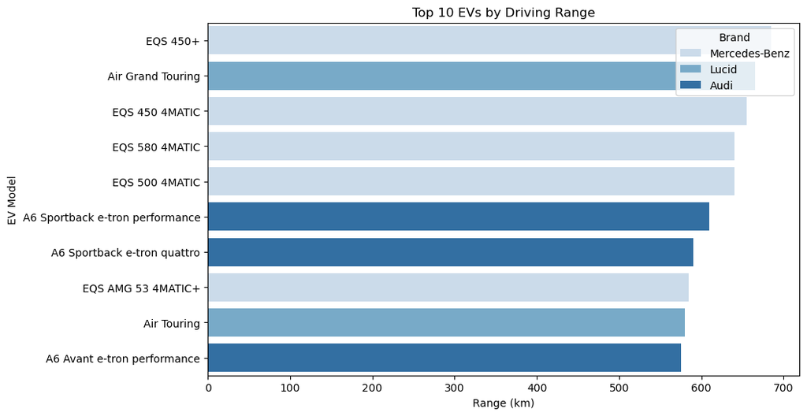

```python
plt.figure(figsize = (10,6))

sns.barplot(
    data = top_range,
    x = 'range_km',
    y = 'model',
    hue = 'brand',
    palette = 'Blues'
)

plt.title("Top 10 EVs by Driving Range")
plt.xlabel('Range (km)')
plt.ylabel('EV Model')
plt.legend(title = 'Brand')
plt.show()
```

Generating a horizontal bar chart using Seaborn to visually compare the top 10 electric vehicle models by their driving range in kilometers. The Mercedes-Benz EQS 450+ ranks as the electric vehicle with the highest driving range in the dataset, reaching nearly 685 km. Mercedes-Benz models dominate the upper half of the ranking (holding multiple top spots like the EQS 450 4MATIC, EQS 580 4MATIC, and EQS 500 4MATIC), while Lucid (Air Grand Touring, Air Touring) and Audi (A6 Sportback and Avant series) also feature prominently among the top 10.

## 2. Which brands offer the best battery capacity?

```python
#Calculating Average Battery Capacity by Brand

brand_battery = (
    df.groupby('brand')['battery_capacity_kWh']
    .mean()
    .sort_values(ascending = False)
    .head(10)
    .reset_index()
)

brand_battery
```

|  | brand | battery_capacity_kWh |
| --- | --- | --- |
| 0 | Lotus | 103.950000 |
| 1 | Rolls-Royce | 102.000000 |
| 2 | Cadillac | 102.000000 |
| 3 | Voyah | 100.000000 |
| 4 | Lucid | 98.666667 |
| 5 | Porsche | 93.865385 |
| 6 | Hongqi | 92.833333 |
| 7 | Polestar | 90.333333 |
| 8 | Mercedes-Benz | 88.983333 |
| 9 | VinFast | 87.700000 |

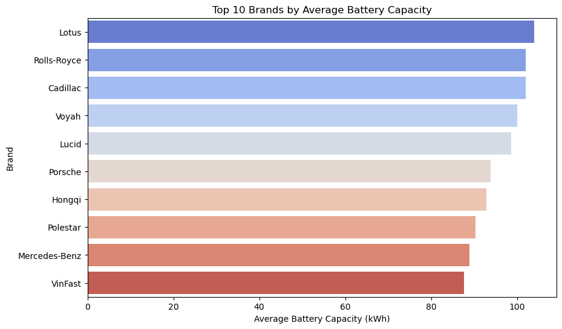

```python
#Visualizing Top Brands by Battery Capacity

plt.figure(figsize = (10,6))

sns.barplot(
    data = brand_battery,
    x = 'battery_capacity_kWh',
    y = 'brand',
    hue = 'brand',
    palette = 'coolwarm'
)

plt.title('Top 10 Brands by Average Battery Capacity')
plt.xlabel('Average Battery Capacity (kWh)')
plt.ylabel('Brand')
plt.show()
```

Generates a Seaborn bar plot displaying the top EV manufacturers ranked by their average battery capacity (kWh) to highlight energy storage trends across brands. Lotus holds the top position with the highest average battery capacity, sitting just above 103 kWh. Luxury and performance manufacturers like Rolls-Royce and Cadillac follow closely behind, both averaging around 102 kWh.

## 3. Does a larger battery provide a longer range?

```python
#Correlating battery capacity and driving range

df[['battery_capacity_kWh', 'range_km']].corr()
```

|  | battery_capacity_kWh | range_km |
| --- | --- | --- |
| battery_capacity_kWh | 1.000000 | 0.880433 |
| range_km | 0.880433 | 1.000000 |

There is a strong positive relationship between battery capacity(kWh) and range(km) indicating that EVs with larger batteries tend to have greater driving ranges.

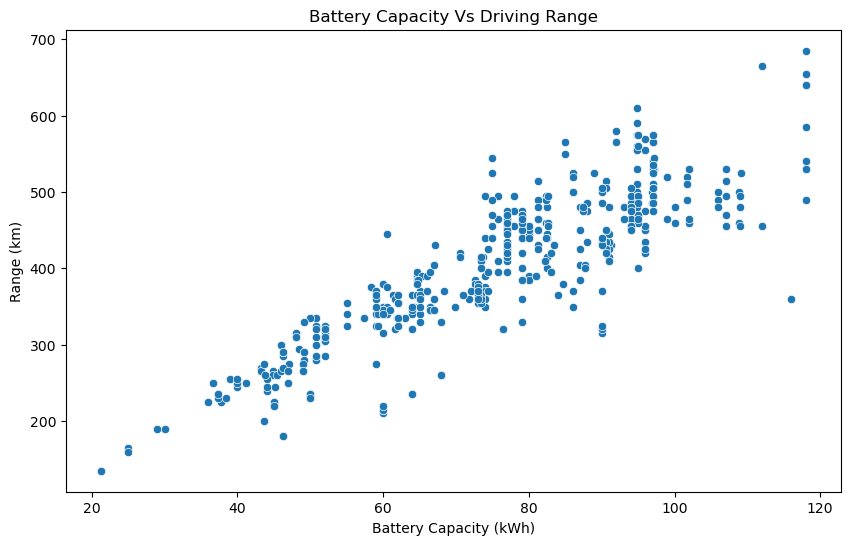

```python
#Creating a scatter plot mapping battery capacity against driving range to examine how energy storage directly impacts vehicle distance capabilities.

plt.figure(figsize = (10,6))

sns.scatterplot(
    data = df,
    x = 'battery_capacity_kWh',
    y = 'range_km'
)

plt.title('Battery Capacity Vs Driving Range')
plt.xlabel('Battery Capacity (kWh)')
plt.ylabel('Range (km)')
plt.show()
```

This diagram maps out individual EV models to display raw data points. It clearly illustrates a strong upward trend: as the battery capacity (kWh) increases, the overall driving range (km) increases proportionally.

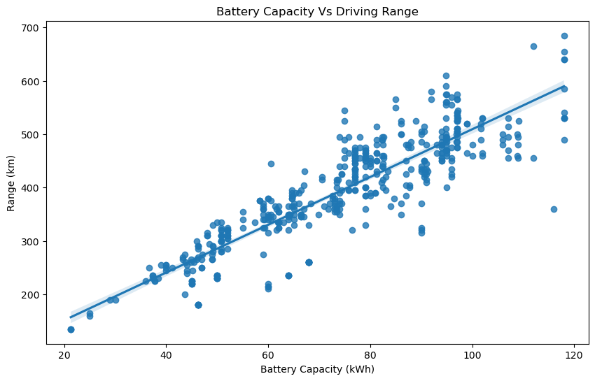

```python
plt.figure(figsize = (10,6))

sns.regplot(
    data = df,
    x = 'battery_capacity_kWh',
    y = 'range_km'
)

plt.title('Battery Capacity Vs Driving Range')
plt.xlabel('Battery Capacity (kWh)')
plt.ylabel('Range (km)')
plt.show()
```

This diagram builds upon the scatter plot by overlaying a fitted linear regression trend line along with a shaded confidence interval band. It mathematically emphasizes the strong positive correlation between battery size and vehicle range, proving that larger battery capacity is the primary driver for extended driving distances in electric vehicles.

## 4. Which EVs have the best energy efficiency?

```python
#Extract Top Efficient EVs

top_efficiency = df[
    ['brand','model', 'efficiency_wh_per_km']
].sort_values(
    by = 'efficiency_wh_per_km',
    ascending = True
).head(10)

top_efficiency
```

|  | brand | model | efficiency_wh_per_km |
| --- | --- | --- | --- |
| 98 | Dacia | Spring Electric 45 | 109 |
| 107 | Fiat | 500e Hatchback 24 kWh | 112 |
| 103 | Fiat | 500e 3+1 24 kWh | 112 |
| 105 | Fiat | 500e Cabrio 24 kWh | 112 |
| 99 | Dacia | Spring Electric 65 | 114 |
| 400 | Tesla | Model 3 RWD (Highland CATL LFP64) | 116 |
| 398 | Tesla | Model 3 Long Range RWD (Highland) | 117 |
| 156 | Hyundai | IONIQ 6 Standard Range 2WD | 117 |
| 108 | Fiat | 500e Hatchback 42 kWh | 118 |
| 149 | Hyundai | INSTER Standard Range | 119 |

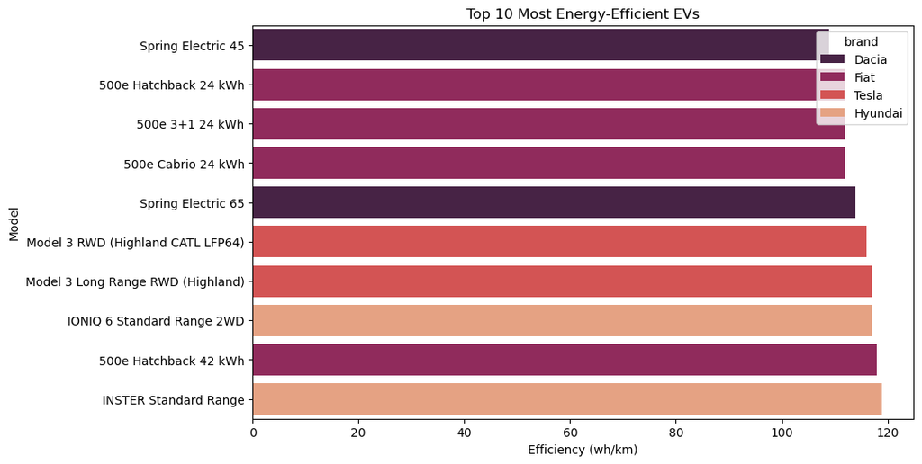

```python
#Plotting a bar chart displaying the models with the highest energy efficiency ratings.

plt.figure(figsize = (10,6))

sns.barplot(
    data = top_efficiency,
    x = 'efficiency_wh_per_km',
    y = 'model',
    hue = 'brand',
    palette = 'rocket'
)

plt.title('Top 10 Most Energy-Efficient EVs')
plt.xlabel('Efficiency (wh/km)')
plt.ylabel('Model')
plt.show()
```

The models at the top of the chart (such as the Spring Electric 45 by Dacia and various 500e variants by Fiat) achieve the lowest energy consumption rates. All top 10 models maintain an outstanding energy efficiency profile under 120 Wh/km, meaning they optimize power consumption exceptionally well over distance.

## 5. Which EVs have the highest top speed?

```python
#Sorting the dataset by top speed (top_speed_kmh) in descending order and filtering out the top 10 fastest electric vehicle models.

top_speed = df[
    ['brand', 'model', 'top_speed_kmh']
    ].sort_values(
        by = 'top_speed_kmh',
        ascending = False
    ).head(10)

top_speed
```

|  | brand | model | top_speed_kmh |
| --- | --- | --- | --- |
| 211 | Maserati | GranTurismo Folgore | 325 |
| 348 | Porsche | Taycan Turbo GT Weissach | 305 |
| 210 | Maserati | GranCabrio Folgore | 290 |
| 347 | Porsche | Taycan Turbo GT | 290 |
| 402 | Tesla | Model S Plaid | 282 |
| 194 | Lucid | Air Grand Touring | 270 |
| 404 | Tesla | Model X Plaid | 262 |
| 399 | Tesla | Model 3 Performance (Highland) | 262 |
| 189 | Lotus | Eletre R | 260 |
| 172 | Kia | EV6 GT | 260 |

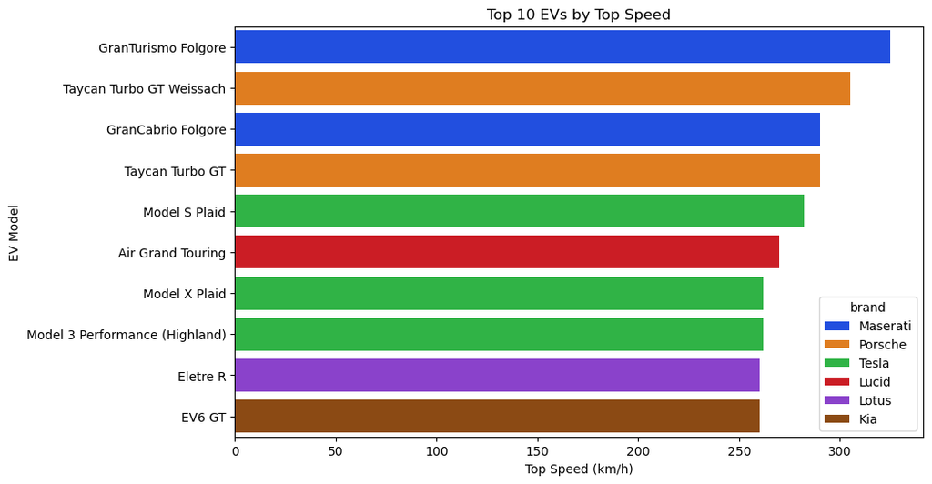

```python
#Generating bar plot utilizing Seaborn to visually represent and comparing the top speed performance of the leading electric vehicles.

plt.figure(figsize = (10,6))

sns.barplot(
    data = top_speed,
    y = 'model',
    x = 'top_speed_kmh',
    hue = 'brand',
    palette = 'bright'
)

plt.title('Top 10 EVs by Top Speed')
plt.ylabel('EV Model')
plt.xlabel('Top Speed (km/h)')
plt.show()
```

## 6. Does efficiency affect driving range?

```python
#Investigating the relationship between vehicle energy consumption and overall driving range using correlation analysis or visualizing to determine how energy economy impacts distance capabilities.

df[['efficiency_wh_per_km','range_km']].corr()
```

|  | efficiency_wh_per_km | range_km |
| --- | --- | --- |
| efficiency_wh_per_km | 1.000000 | 0.022943 |
| range_km | 0.022943 | 1.000000 |

The efficiency value of an EV does not show a strong direct linear relationship with its driving range in its dataset.

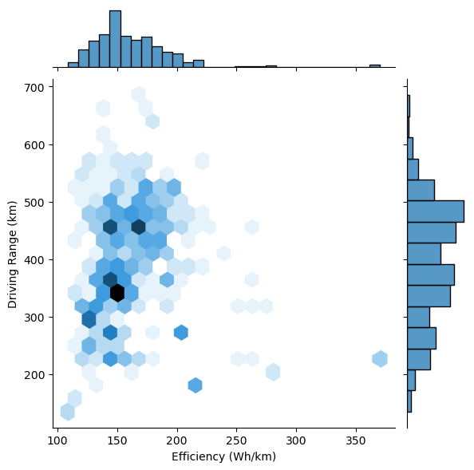

```python
#Using jointplot with a hexagonal binning style to visualize both the individual distributions and the joint density/relationship between energy efficiency and driving range.

plt.figure(figsize = (10,6))

sns.jointplot(
    data =df,
    x = 'efficiency_wh_per_km',
    y = 'range_km',
    kind = 'hex'
)

plt.xlabel('Efficiency (Wh/km)')
plt.ylabel('Driving Range (km)')
plt.show()
```

The vast majority of electric vehicles cluster heavily between 100-200 Wh/km in efficiency and 300-500 km in driving range, represented by the darkest blue hexagonal bins. But we cannot see any steep upward or downward linear trend between two variables.

## 7. Which brands have the highest fast-charging power?

```python
#Grouping the top 10 brands based on their fast-charging capabilities

brand_charging = (
    df.groupby('brand')['fast_charging_power_kw_dc']
    .mean()
    .sort_values(ascending = False)
    .head(10)
    .reset_index()
)

brand_charging
```

|  | brand | fast_charging_power_kw_dc |
| --- | --- | --- |
| 0 | Porsche | 252.000000 |
| 1 | Lotus | 249.500000 |
| 2 | Genesis | 190.000000 |
| 3 | Audi | 180.142857 |
| 4 | Maserati | 172.333333 |
| 5 | XPENG | 170.222222 |
| 6 | Lucid | 168.000000 |
| 7 | Cadillac | 165.000000 |
| 8 | Zeekr | 162.555556 |
| 9 | Hyundai | 152.571429 |

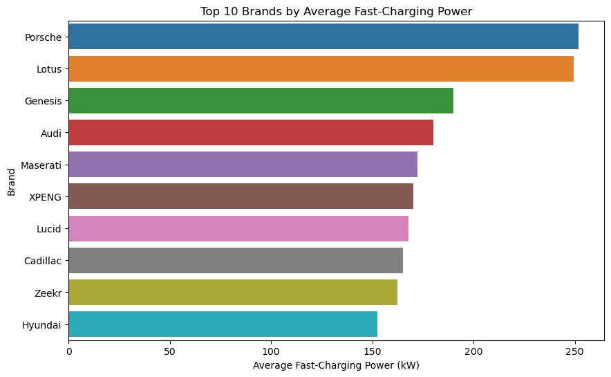

```python
#Generating a horizontal bar chart to visually rank and compare the top 10 automotive brands based on their average fast-charging power capabilities.


plt.figure(figsize=(10, 6))

sns.barplot(
    data=brand_charging,
    x='fast_charging_power_kw_dc',
    y='brand',
    hue = 'brand'
)

plt.title('Top 10 Brands by Average Fast-Charging Power')
plt.xlabel('Average Fast-Charging Power (kW)')
plt.ylabel('Brand')
plt.show()
```

Porsche and Lotus lead the market by a significant margin, both boasting average fast-charging power capacities right around the 250 kW. Genesis and Audi follow as strong mid-to-high tier contenders in fast-charging capabilities.

## 8. Does higher charging power correspond to larger batteries?

```python
#Computing the correlation matrix between fast-charging power and battery capacity (kWh) to mathematically evaluate their relationship.

df[['fast_charging_power_kw_dc', 'battery_capacity_kWh']].corr()
```

|  | fast_charging_power_kw_dc | battery_capacity_kWh |
| --- | --- | --- |
| fast_charging_power_kw_dc | 1.000000 | 0.728557 |
| battery_capacity_kWh | 0.728557 | 1.000000 |

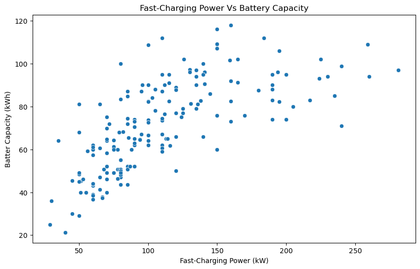

```python
#Generating a scatter plot for mapping fast-charging power against battery capacity to visually inspect how the two variables move together.


plt.figure(figsize = (10,6))

sns.scatterplot(
    data = df,
    x = 'fast_charging_power_kw_dc',
    y = 'battery_capacity_kWh'
)

plt.title('Fast-Charging Power Vs Battery Capacity')
plt.xlabel('Fast-Charging Power (kW)')
plt.ylabel('Batter Capacity (kWh)')
plt.show()
```

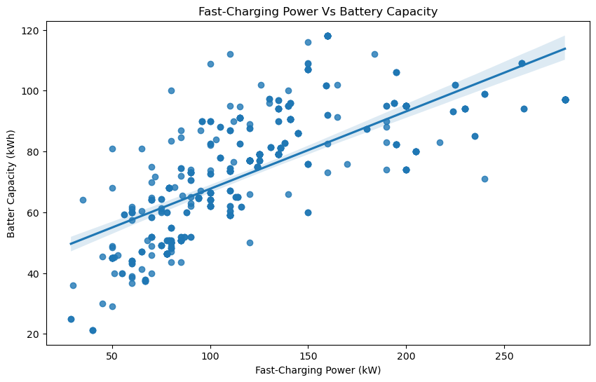

```python
#Plotting a regression plot featuring a fitted trend line and confidence interval to clearly display the positive linear relationship between charging power and battery size.

plt.figure(figsize = (10,6))

sns.regplot(
    data = df,
    x = 'fast_charging_power_kw_dc',
    y = 'battery_capacity_kWh'
)

plt.title('Fast-Charging Power Vs Battery Capacity')
plt.xlabel('Fast-Charging Power (kW)')
plt.ylabel('Batter Capacity (kWh)')
plt.show()
```

The correlation matrix shows a value of 0.728557, which indicates a strong positive linear relationship between fast-charging power and battery capacity.As seen in the regression plot, electric vehicles with larger battery capacities (higher kWh) tend to support significantly higher fast-charging power (higher kW DC). Conversely, cars with smaller batteries generally have lower fast-charging capabilities.

## 9. Which body types are most common?

```python
#Computing the frequency distribution of various vehicle body-type

body_types = df['car_body_type'].value_counts()

body_types
```

```
car_body_type
SUV                    244
Sedan                   63
Hatchback               57
Small Passenger Van     47
Liftback Sedan          33
Station/Estate          27
Cabriolet                5
Coupe                    2
Name: count, dtype: int64
```

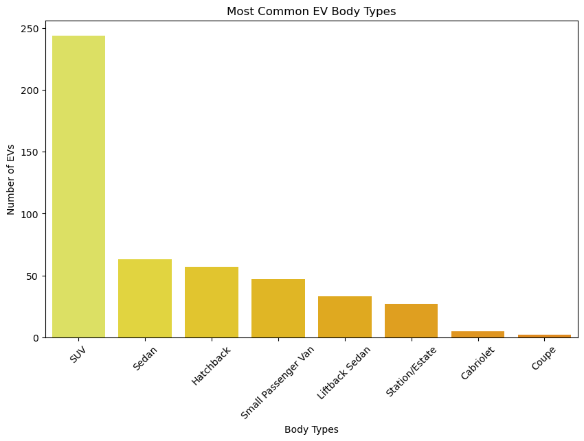

```python
#Generating a count plot of different car body types in the EV market that is ordered from highest to lowest frequency

plt.figure(figsize = (10,6))

sns.countplot(
    data = df,
    x = 'car_body_type',
    order = df['car_body_type'].value_counts().index,
    palette = 'Wistia'
)

plt.title('Most Common EV Body Types')
plt.xlabel('Body Types')
plt.ylabel('Number of EVs')
plt.xticks(rotation = 45)
plt.show()
```

The output clearly shows that SUVs are by far the most popular vehicle body type in the dataset (with 244 models), significantly outpacing other designs. Body-types like Cabriolet and Coupes represent a very small fraction of the available electric vehicle models.

## 10. Which vehicle segments have the highest range?

```python
segment_range = (
    df.groupby('segment')['range_km']
    .mean()
    .sort_values(ascending = False)
    .reset_index()
)

segment_range
```

|  | segment | range_km |
| --- | --- | --- |
| 0 | F - Luxury | 525.000000 |
| 1 | JE - Executive | 484.107143 |
| 2 | E - Executive | 478.500000 |
| 3 | I - Luxury | 465.000000 |
| 4 | JF - Luxury | 449.666667 |
| 5 | D - Large | 447.857143 |
| 6 | JD - Large | 430.344828 |
| 7 | G - Sports | 410.000000 |
| 8 | JC - Medium | 389.340659 |
| 9 | C - Medium | 355.000000 |
| 10 | JB - Compact | 307.159091 |
| 11 | JA - Mini | 277.500000 |
| 12 | B - Compact | 252.241379 |
| 13 | N - Passenger Van | 245.638298 |
| 14 | A - Mini | 183.333333 |

```python
#To get top ten segment range

segment_range.head(10)
```

|  | segment | range_km |
| --- | --- | --- |
| 0 | F - Luxury | 525.000000 |
| 1 | JE - Executive | 484.107143 |
| 2 | E - Executive | 478.500000 |
| 3 | I - Luxury | 465.000000 |
| 4 | JF - Luxury | 449.666667 |
| 5 | D - Large | 447.857143 |
| 6 | JD - Large | 430.344828 |
| 7 | G - Sports | 410.000000 |
| 8 | JC - Medium | 389.340659 |
| 9 | C - Medium | 355.000000 |

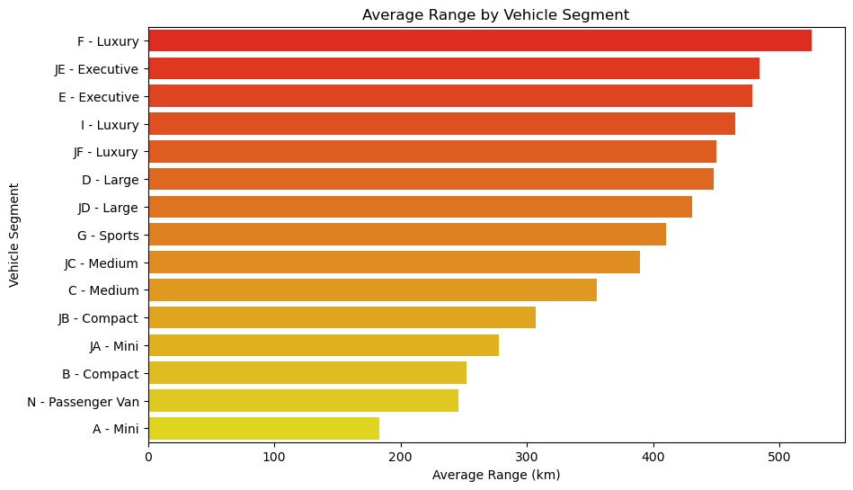

```python
plt.figure(figsize=(10, 6))

sns.barplot(
    data=segment_range,
    x='range_km',
    y='segment',
    palette = 'autumn'
)

plt.title('Average Range by Vehicle Segment')
plt.xlabel('Average Range (km)')
plt.ylabel('Vehicle Segment')
plt.show()
```

F-Luxury vehicles lead all categories by a notable margin, boasting the highest average driving range at over 520 km. Smaller vehicle classifications, such as B-Compact, N-Passenger Van, and A-Mini, exhibit the lowest average driving ranges, with A-Mini sitting at the bottom under 200 km. This directly correlates with smaller battery capacities typically built into smaller, city-oriented car models.

## 11. Which drivetrain - FWD, RWD or AWD-has better performance?

```python
df['drivetrain'].value_counts()
```

```
drivetrain
AWD    191
FWD    156
RWD    131
Name: count, dtype: int64
```

```python
#To compare average performance of the drivetrain

drivetrain_performance = df.groupby('drivetrain')[
    [
        'range_km',
        'top_speed_kmh',
        'acceleration_0_100_s',
        'torque_nm',
        'efficiency_wh_per_km'
    ]
].mean().round(2)

drivetrain_performance
```

| drivetrain | range_km | top_speed_kmh | acceleration_0_100_s | torque_nm | efficiency_wh_per_km |
| --- | --- | --- | --- | --- | --- |
| AWD | 453.77 | 210.73 | 4.55 | 741.22 | 175.09 |
| FWD | 298.01 | 154.29 | 9.73 | 271.25 | 153.17 |
| RWD | 418.17 | 185.84 | 6.89 | 420.41 | 156.73 |

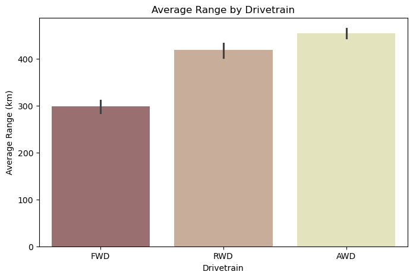

```python
#Average Range by Drivetrain

plt.figure(figsize=(8, 5))

sns.barplot(
    data=df,
    x='drivetrain',
    y='range_km',
    palette = 'pink'
)

plt.title('Average Range by Drivetrain')
plt.xlabel('Drivetrain')
plt.ylabel('Average Range (km)')
plt.show()
```

All-Wheel Drive (AWD) vehicles provide the highest average driving range, sitting at approximately 450 km. This correlates with AWD typically being paired with larger battery packs in higher-end or longer-range configurations. Rear-Wheel Drive (RWD) vehicles maintain a strong average range of around 420 km. Front-Wheel Drive (FWD) vehicles record the lowest average driving range, averaging roughly 300 km, reflecting their presence in smaller, affordable commuter cars built with smaller battery capacities.

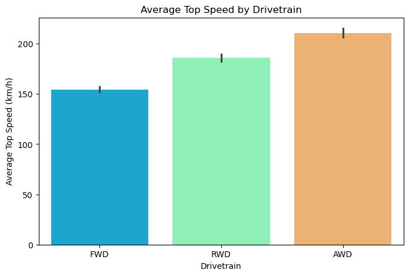

```python
#Average Top Speed by Drivetrain

plt.figure(figsize=(8, 5))

sns.barplot(
    data=df,
    x='drivetrain',
    y='top_speed_kmh',
    palette = 'rainbow'
)

plt.title('Average Top Speed by Drivetrain')
plt.xlabel('Drivetrain')
plt.ylabel('Average Top Speed (km/h)')
plt.show()
```

All-Wheel Drive (AWD) vehicles achieve the highest average top speed, reaching approximately 210 km/h. This aligns with AWD typically being equipped on high-performance, dual-motor, or luxury electric vehicles. Rear-Wheel Drive (RWD) vehicles sit in the middle tier, averaging around 185 km/h. Front-Wheel Drive (FWD) vehicles record the lowest average top speed, sitting at roughly 155 km/h, reflecting their common use in smaller, efficiency-focused, and city-oriented models.

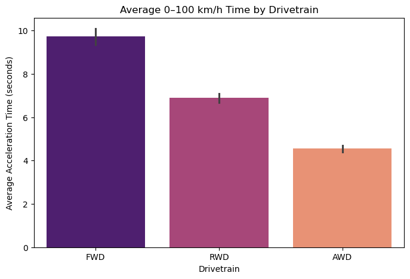

```python
#Average Time by Drivetrain

plt.figure(figsize=(8, 5))

sns.barplot(
    data=df,
    x='drivetrain',
    y='acceleration_0_100_s',
    palette = 'magma'
)

plt.title('Average 0–100 km/h Time by Drivetrain')
plt.xlabel('Drivetrain')
plt.ylabel('Average Acceleration Time (seconds)')
plt.show()
```

All-Wheel Drive (AWD) vehicles achieve the fastest average acceleration times, taking roughly 4.6 seconds to reach 0–100 km/h. This is due to superior traction and power distribution across all wheels. Rear-Wheel Drive (RWD) vehicles sit in the middle tier, averaging around 6.9 seconds. Front-Wheel Drive (FWD) vehicles record the highest average acceleration times, taking nearly 9.7 seconds on average to hit 100 km/h, typically reflecting more budget-friendly, city-oriented, or lower-horsepower EV configurations.

## 12. Which body type provides the largest cargo capacity?

```python
#Grouping the dataset by vehicle body-type and calculating the mean cargo volume in liters for each category and sorting them in descending order

body_cargo = (
    df.groupby('car_body_type')['cargo_volume_l']
    .mean()
    .sort_values(ascending = False)
    .reset_index()
)

body_cargo
```

|  | car_body_type | cargo_volume_l |
| --- | --- | --- |
| 0 | Small Passenger Van | 899.888889 |
| 1 | Liftback Sedan | 505.818182 |
| 2 | Station/Estate | 489.481481 |
| 3 | SUV | 478.396694 |
| 4 | Sedan | 446.682540 |
| 5 | Coupe | 325.000000 |
| 6 | Hatchback | 317.631579 |
| 7 | Cabriolet | 203.800000 |

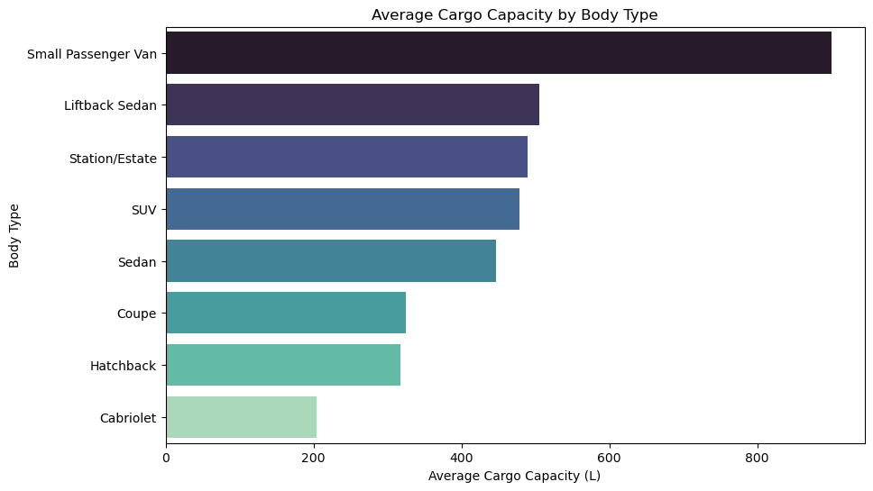

```python
plt.figure(figsize=(10, 6))

sns.barplot(
    data=body_cargo,
    x='cargo_volume_l',
    y='car_body_type',
    palette = 'mako'
)

plt.title('Average Cargo Capacity by Body Type')
plt.xlabel('Average Cargo Capacity (L)')
plt.ylabel('Body Type')
plt.show()
```

Small Passenger Vans provide by far the largest average cargo capacity, averaging around 899 liters, which is significantly higher than any other category.Hatchbacks, and Cabriolets offer the least amount of average cargo space, with Cabriolets providing the lowest at around 203 liters.

## 13. Which Charging ports are Most Common?

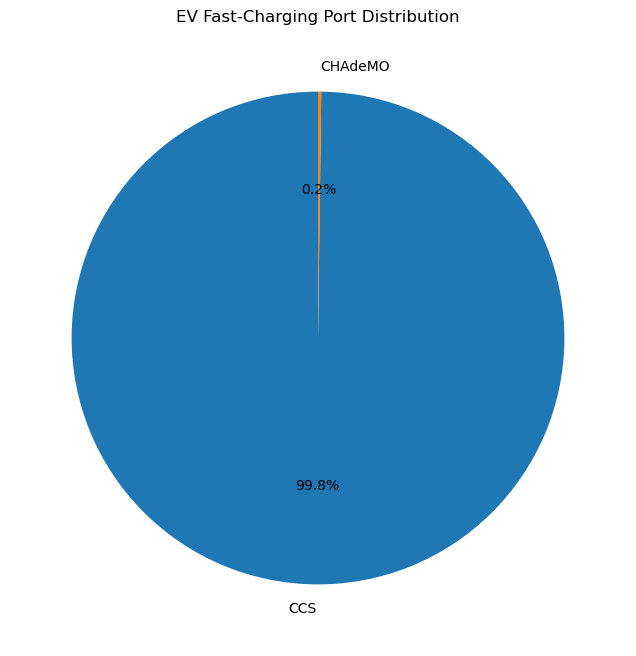

```python
#Counting the frequency of different fast-charging port types and generating a Matplotlib pie chart to show the proportional distribution across the dataset.


port_counts = df['fast_charge_port'].value_counts()

plt.figure(figsize=(8, 8))

plt.pie(
    port_counts,
    labels=port_counts.index,
    autopct='%1.1f%%',
    startangle=90,
)

plt.title('EV Fast-Charging Port Distribution')
plt.show()
```

The pie chart clearly shows that the CCS (Combined Charging System) port is overwhelmingly the industry standard, accounting for 99.8% of the electric vehicles in the dataset. While CHAdeMO ports make up an extremely small fraction (0.2%), reflecting its phasing out in modern EV designs.